# Statistics

## Correlations

- *Pearson* correlation - parametric
  - $r$ pearson coefficient
    $$r = \frac{{}\sum_{i=1}^{n} (x_i - \overline{x})(y_i - \overline{y})}
    {\sqrt{\sum_{i=1}^{n} (x_i - \overline{x})^2(y_i - \overline{y})^2}}$$
  - Formula for the $t$ test fro the correlation coefficient:
    $$t = r\sqrt\frac{n-2}{1-r^2}$$
    ___________with degrees of freedom equal to $n-2$
  - Example:

```r
# dataset hypotheses?
x<-students$height
y<-students$shoesize
s<-students[,1:2] # a matrix
# Pearson correlation
# cor(x,y)
# cor(s)
cor.test(x,y)
```

```
##
##  Pearson's product-moment correlation
##
## data:  x and y
## t = 13.218, df = 8, p-value = 1.023e-06
## alternative hypothesis: true correlation is not equal to 0
## 95 percent confidence interval:
##  0.9061337 0.9949256
## sample estimates:
##       cor
## 0.9778637
```

This relationship is usually represented with it confident interval on a scatter plot.

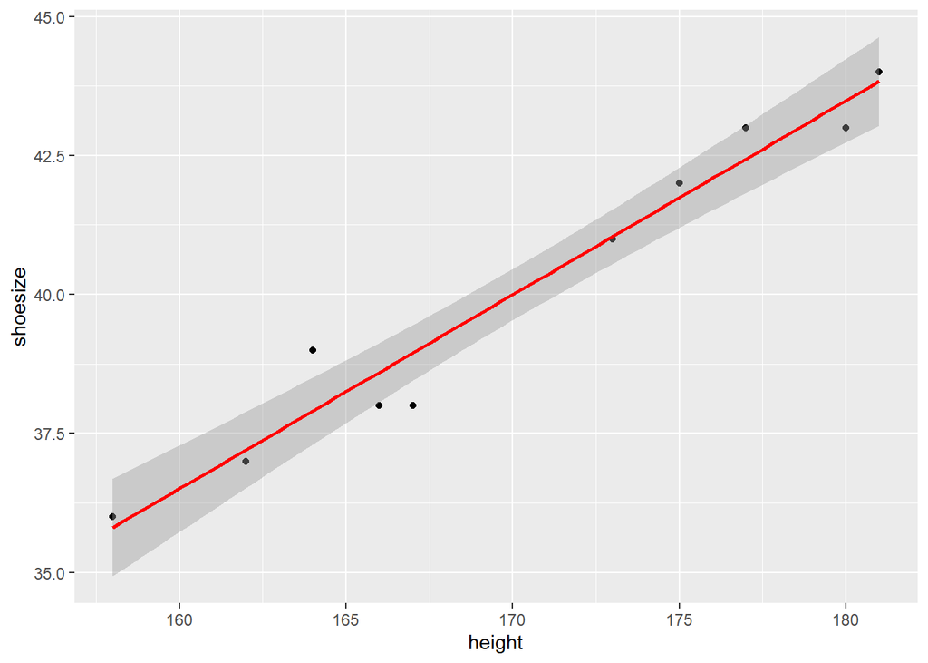

```r
ggplot(students, aes(x = height, y = shoesize)) +
  geom_point() +
  stat_smooth(method = "lm", col = "red")
```

- *Spearman* correlation - non-parametric

It is based on ranking, and tests the existence of a monotonic relationship.

```r
# Spearman correlation (monotonic)
# cor(x,y, method ='spearman')
cor.test(x,y, method ='spearman')
```

```
##
##  Spearman's rank correlation rho
##
## data:  x and y
## S = 7.0397, p-value = 1.377e-05
## alternative hypothesis: true rho is not equal to 0
## sample estimates:
##       rho
## 0.9573349
```

**The example below illustrates on the importance of running both types of correlation**

```r
w<-(1:100)
z<-exp(x)
cor.test(w,z,method='pearson') # super low
cor.test(w,z,method='spearman') #super high
```

**Practice 7.2** Play with modifying a value from the student data set and check how $t$ and $p$ values are affected by this change. Examine change in the confidence interval.

## Chi-square test

It is a goodness-of-fit test: observed vs theoretical.

- Casino example

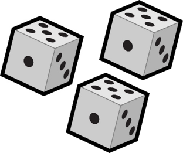

```r
#Cast 240 times a die. We counted occurrence of 1,2,3,4,5,6
die<-data.frame(obs=c(55,44,35,45,31,30), row.names=c('Cast1','Cast2','Cast3','Cast4','Cast5','Cast6'))
die #Is this die fair? Define H0 and H1.
```

```
##       obs
## Cast1  55
## Cast2  44
## Cast3  35
## Cast4  45
## Cast5  31
## Cast6  30
```

Assumption: all results are equally probably (H0, uniform distribution).

```r
chisq.test(die)
```

```
##
##  Chi-squared test for given probabilities
##
## data:  die
## X-squared = 11.8, df = 5, p-value = 0.03763
```

```r
# I am cheating
```

- Hardy-Weinberg

A common biological application of a Chi-square test is the Hardy-Weinberg equilibrium. Genotypes at the Hardy-Weinberg equilibrium will follow: *p*2 + 2*pq* + *q*2 = 1 at panmixia (random mating, *p* and *q* represent allele frequency). In this case, we want to compare our observation to a theoretical distribution.

```r
obs <- c(750, 50, 200)
exp <- c(0.60, 0.35, 0.05)
chisq.test (x=obs, p=exp)
```

```
##
##  Chi-squared test for given probabilities
##
## data:  obs
## X-squared = 744.64, df = 2, p-value < 2.2e-16
```

- Frequencies

Chi-square test can simply be used to compare the distribution of frequencies in two populations:

```r
F <- matrix(nrow=4,ncol=2,data=c(33,14, 8,18,31,25,14,12))
chisq.test(F) # alternative see `fisher.test`
```

```
##
##  Pearson's Chi-squared test
##
## data:  F
## X-squared = 5.4974, df = 3, p-value = 0.1388
```

## Student t-test

```r
# One sample
t.test (students$height, mu=170)
```

```
##
##  One Sample t-test
##
## data:  students$height
## t = 0.11899, df = 9, p-value = 0.9079
## alternative hypothesis: true mean is not equal to 170
## 95 percent confidence interval:
##  164.5966 176.0034
## sample estimates:
## mean of x
##     170.3
```

```r
# Two sample (with equal variances)
t.test (students$height~students$gender, var.equal = TRUE)
```

```
##
##  Two Sample t-test
##
## data:  students$height by students$gender
## t = -6.2988, df = 8, p-value = 0.0002331
## alternative hypothesis: true difference in means between group female and group male is not equal to 0
## 95 percent confidence interval:
##  -18.852202  -8.747798
## sample estimates:
## mean in group female   mean in group male
##                163.4                177.2
```

```r
# Two sample (with unequal variances, default option when using t.test)
t.test (students$height~students$gender)
```

```
##
##  Welch Two Sample t-test
##
## data:  students$height by students$gender
## t = -6.2988, df = 7.9646, p-value = 0.0002375
## alternative hypothesis: true difference in means between group female and group male is not equal to 0
## 95 percent confidence interval:
##  -18.856113  -8.743887
## sample estimates:
## mean in group female   mean in group male
##                163.4                177.2
```

```r
# Two sample paired t.test
t.test (students$height~students$gender, paired=T)
```

```
##
##  Paired t-test
##
## data:  students$height by students$gender
## t = -9.0213, df = 4, p-value = 0.0008362
## alternative hypothesis: true mean difference is not equal to 0
## 95 percent confidence interval:
##  -18.047144  -9.552856
## sample estimates:
## mean difference
##           -13.8
```

In the case of a two samples assuming equal variances, the *t* statistic is obtained as following:

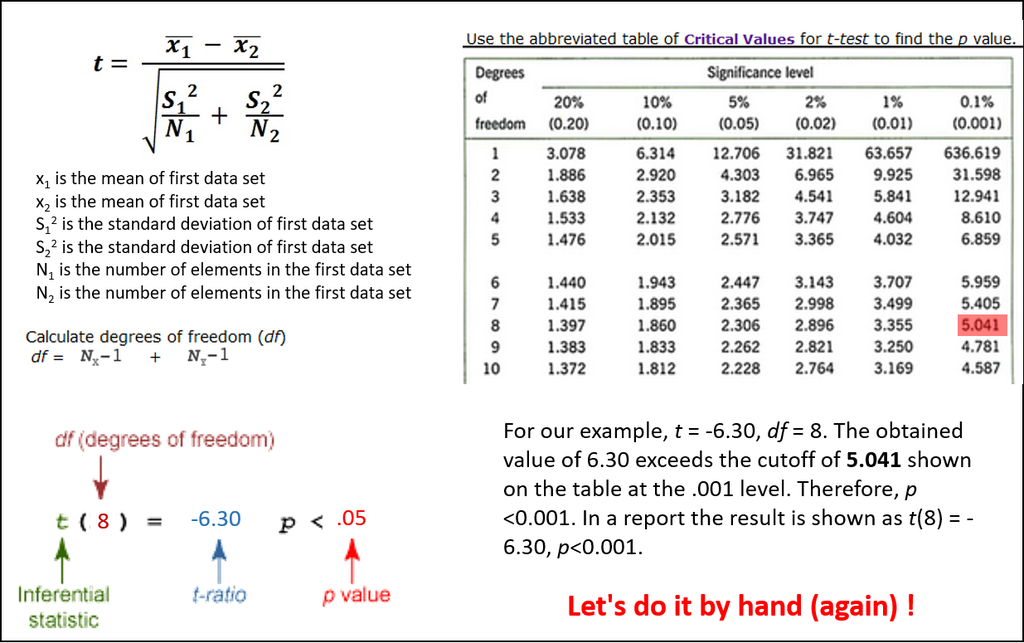

**Practice 7.3** Using `iris`. Does `Sepal.Lenght` differ between species `setosa` and `versicolor`? Does `Sepal.Lenght` differ between `virginica` and `versicolor`? Make a plot, define your hypotheses, test hypotheses

```r
## set <- iris[iris$Species == "setosa", ]$Sepal.Length
## ver <- iris[iris$Species == "versicolor", ]$Sepal.Length
## vir <- iris[iris$Species == "virginica", ]$Sepal.Length
##
## setver <- t.test(set, ver, paired = FALSE, alternative = "two.sided", var.equal = FALSE)
## vervir <- t.test(ver, vir, paired = FALSE, alternative = "two.sided", var.equal = FALSE)
```

## Mann-Whitney

A non-parametric solution for the comparison of two samples: Mann-Whitney U-test (independent) or Wilcoxon W-test (dependant)

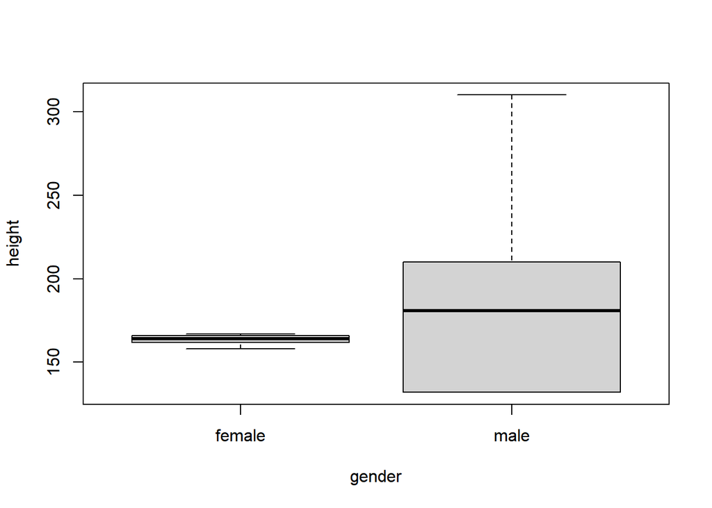

```r
# Normality plot & test
students$height[6]<-132
students$height[10]<-310
students$height[8]<-132
students$height[9]<-210
boxplot(height~gender, students)
```

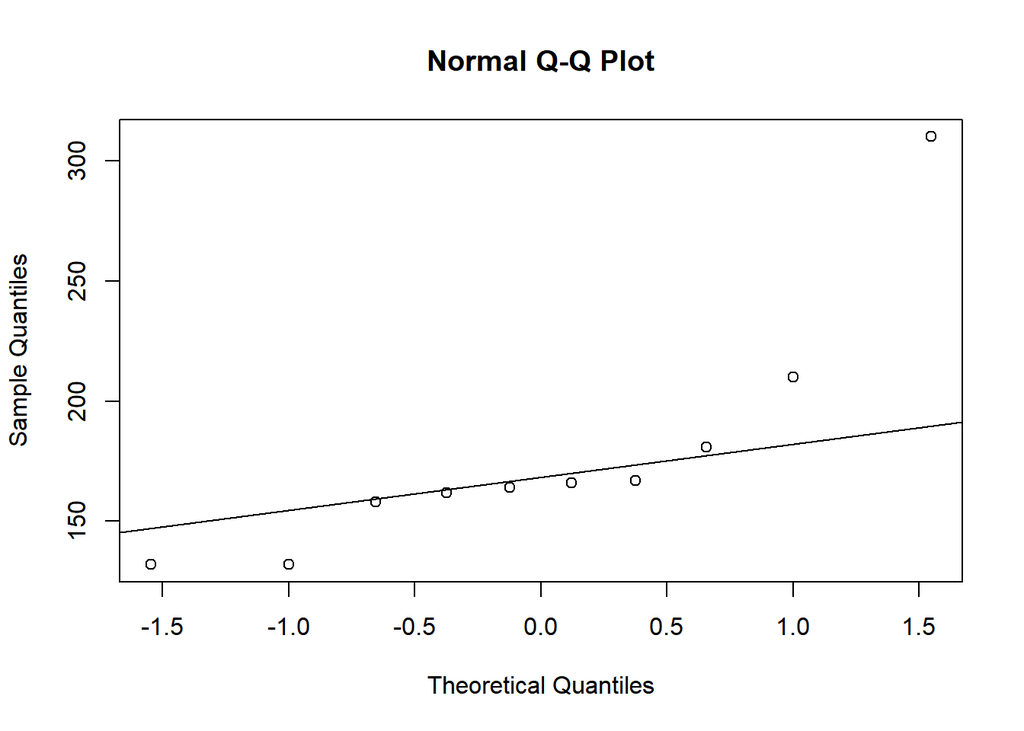

```r
qqnorm(students$height)
qqline(students$height)
```

```r
shapiro.test(students$height) # if data are not normal
```

```
##
##  Shapiro-Wilk normality test
##
## data:  students$height
## W = 0.74759, p-value = 0.003336
```

```r
wilcox.test (students$height~students$gender)
```

```
##
##  Wilcoxon rank sum test with continuity correction
##
## data:  students$height by students$gender
## W = 10, p-value = 0.6752
## alternative hypothesis: true location shift is not equal to 0
```

## Variances

Variance tests are used to determine if the variances of two (or more) populations are equal. F-test are generally very sensitive to the non-normality of the data as you can imagine from the previous `boxplot`. The **homoscedasticity** (or **homogeneity of variance**) is an important condition in parametric statistics.

```r
# Test of variance: we test HO: homogeneous, H1:heterogeneous
fligner.test (students$height ~ students$gender)
```

```
##
##  Fligner-Killeen test of homogeneity of variances
##
## data:  students$height by students$gender
## Fligner-Killeen:med chi-squared = 3.2305, df = 1, p-value = 0.07228
```

Another example using the `ToothGrowth` data set (`car` package) on multiple groups

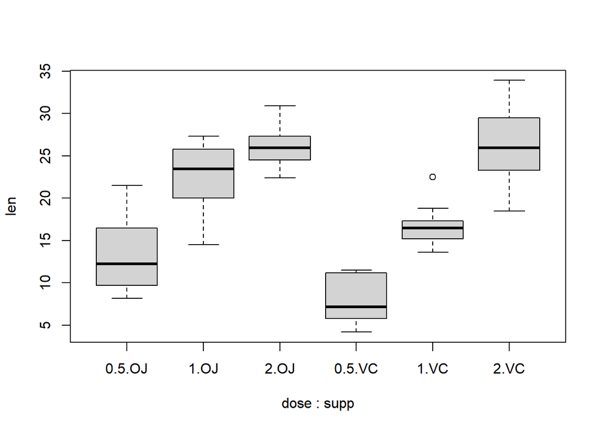

```r
tg<-ToothGrowth
tg$dose<-factor(tg$dose)
boxplot(len~dose*supp, data=tg)
```

```r
# also work with: boxplot(len ~ interaction (dose,supp), data=tg)
# or: plot(len ~ interaction (dose,supp), data=tg)
bartlett.test(len~interaction (supp,dose),data=ToothGrowth) # sensitivity non-normality +++
```

```
##
##  Bartlett test of homogeneity of variances
##
## data:  len by interaction(supp, dose)
## Bartlett's K-squared = 6.9273, df = 5, p-value = 0.2261
```

```r
leveneTest(len~interaction (supp,dose),data=ToothGrowth) # sensitivity non-normality ++
```

```
## Levene's Test for Homogeneity of Variance (center = median)
##       Df F value Pr(>F)
## group  5  1.7086 0.1484
##       54
```

```r
fligner.test(len~interaction (supp,dose),data=ToothGrowth) # sensitivity non-normality +
```

```
##
##  Fligner-Killeen test of homogeneity of variances
##
## data:  len by interaction(supp, dose)
## Fligner-Killeen:med chi-squared = 7.7488, df = 5, p-value = 0.1706
```

**Practice 7.4** Create your **own** `my.t.test` function (e.g. you will not use the above `t.test` function but you will code your own function). You will probably need to check at `?pt` in order to extract the p-value. You can look at `getAnywhere("t.test.default")` for the actual source code of the `t.test` function. Please use your customized function to test the effect of `treatment` on *length* at various *days* in the `rairuoho` dataset. Interpret.